# Two Chip Cascade User Guide

## Overview

The [Two-chip mmWave Cascade Reference Design](https://www.ti.com/tool/TIDA-020047) pairs two AWR2243 radar transceivers and one [AM273x](https://www.ti.com/product/AM2732) radar signal processor on a single PCB with integrated antennas to demonstrate a simple and robust cascaded radar system. Each AWR2243 transceiver has 4 receivers and 3 transmitters, enabling a total of 8 receivers and 6 transmitters when cascaded. These are utilized to create a virtual antenna array with 48 channels in the azimuth.

[figure not shown]

This larger virtual antenna array enables finer angular resolution, allowing the radar system to distinguish between clustered objects with same velocities (such as cars in adjacent lanes) at greater distances. For comparison, the AWR2243-2X-CAS-EVM achieves an azimuth angular resolution of 3° while the AWR2944EVM achieves 10°.

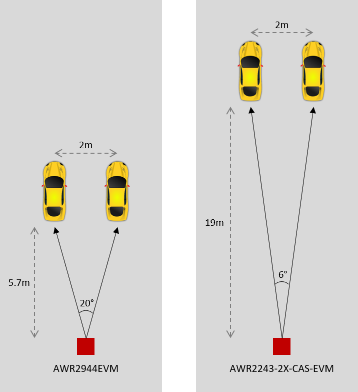

The AM273x configures and controls the two AWR2243 transceivers, as well as process received data for object detection and tracking. It configures the transceivers via SPI, receives ADC data via two CSI2 channels, and sends detected and/or tracked object data to the host PC via UART. The AM273x includes a 450MHz C66x DSP, a 400MHz Arm Cortex-R5F, and a 400MHz hardware accelerator (HWA). The HWA enhances performance by handling common radar signal processing tasks such as FFT, CFAR, and interference mitigation.

## Requirements

### Hardware Requirements

| Item | Details |
| --- | --- |
| Device | AWR2243-2X-CAS-EVM |
| Computer | PC with Windows 10 or higher. If a laptop is used, please use the ‘Higher Performance’ power plan in Windows. |
| Micro USB Cable |  |
| Power Supply | 12V, >2A with 2.1-mm barrel jack (center positive) |

### Software Requirements

| Tool | Version | Required For | Download Link |
| --- | --- | --- | --- |
| TI mmWave MCU+SDK | 04.04.00.01 | Building the application, flashing the image | [Link](https://www.ti.com/tool/MMWAVE-MCUPLUS-SDK) |
| Python | 3.x | Flashing | [Link](https://www.python.org/downloads/) |
| Python Libraries: pyserial, xmodem, tqdm | Latest | Flashing | [pyserial](https://pypi.org/project/pyserial/), [xmodem](https://pypi.org/project/xmodem/), [tqdm](https://pypi.org/project/tqdm/) |
| Code Composer Studio | 12 | Rebuilding the Lab | [Link](https://www.ti.com/tool/CCSTUDIO) |
| MATLAB Runtime | R2023b | Data visualization | [Link](https://www.mathworks.com/products/compiler/matlab-runtime.html) |
| Sysconfig | 1_22.0 | Rebuilding the Lab | [Link](https://www.ti.com/tool/SYSCONFIG) |

- Note: Ensure CCS has Sitara AM2xxx product family installed.

## Quick Start

The quick start guide covers setting up the EVM for flash (UART boot) and run (QSPI boot) modes, flashing the firmware, and running the demo.

### Setup the EVM for UART Boot Mode (Flash mode)

Connect the EVM to the PC via a micro USB cable.

Set the EVM to UART boot mode to enable flashing by attaching the J6 jumper to the bottom two pins:

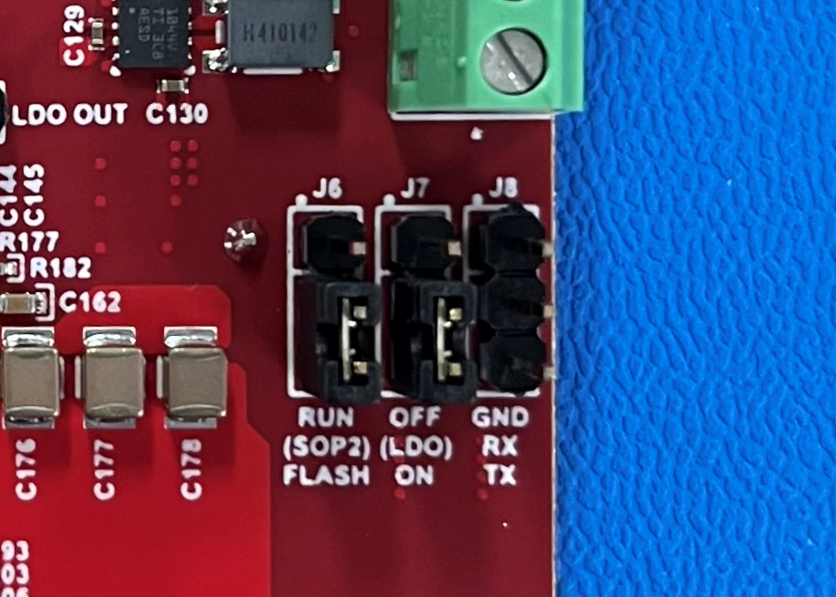

Connect the EVM to the power supply.

### Flash Lab Binaries

Note: The full Radar Toolbox installation path is referred to as `{RTB_DIR}`, e.g. `C:/ti/radar_toolbox_X_XX_XX_XX`.

Note: The full demo path is referred to as `{LAB_DIR}`, e.g. `{RTB_DIR}/source/ti/examples/Automotive_ADAS_and_Parking/mmwave_2_chip_cascade/`.

After installing the TI mmWave MCU+SDK, navigate to `{RTB_DIR}/source/ti/examples/Automotive_ADAS_and_Parking/mmwave_2_chip_cascade/prebuilt_binaries` and open a Command Prompt window (type `cmd` in the folder search bar). Run the following command to flash the firmware:

```
python C:/ti/mmwave_mcuplus_sdk_04_04_00_01/mcu_plus_sdk_awr294x_08_06_00_28/tools/boot/uart_uniflash.py -p COM{X} --cfg=demo.cfg
```

To identify the correct COM port number to be used, go to the Device Manager window on your PC. Under ports, the ports corresponding to the EVM should appear as:

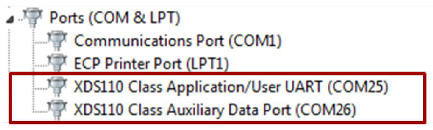

The Application/User UART port should be used for flashing the firmware.

Upon successfully flashing, the Command Prompt will display:

```
All commands from config file are executed !!!
```

### Setup the EVM for QSPI Boot Mode (Run mode)

Set the EVM to QSPI boot mode to enable Run mode by moving the J6 jumper to the top two pins:

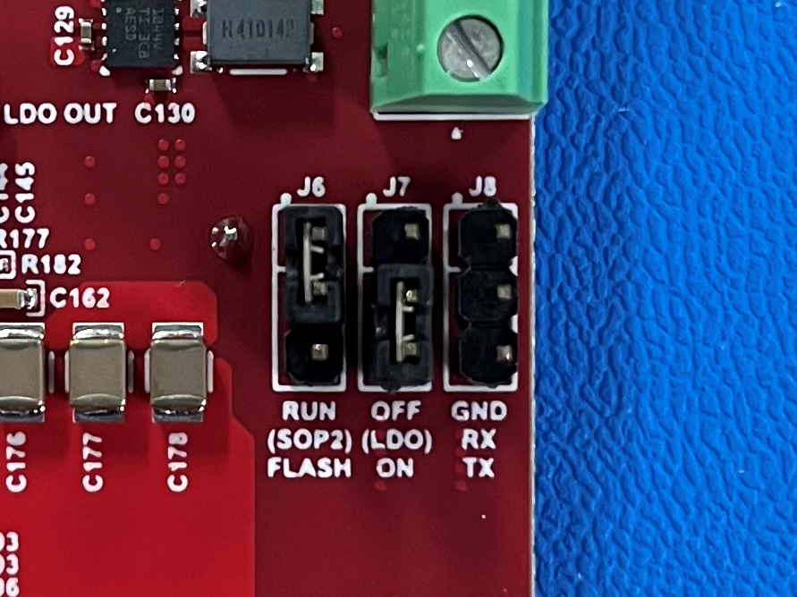

Power cycle the EVM (Turn the power off and on).

### Running the Lab

Both the executable and MATLAB code for the visualizer are provided in the Radar Toolobox at: `{RTB_DIR}/tools/visualizer/mmwave_2_chip_cascade_visualizer`

Several example configuration files are provided in `{RTB_DIR}/source/ti/examples/Automotive_ADAS_and_Parking/mmwave_2_chip_cascade/chirp_configs`:

| Name | Max Range (m) | Max Velocity (m/s) |
| --- | --- | --- |
| cascade_shortrange.cfg | 15 | 18 |
| cascade_longrange.cfg | 150 | 36 |
| cascade_veryLongRange.cfg | 250 | 36 |
| cascade_shortrange_calib.cfg | For calibration |  |

#### Running the Visualizer Executable

In the visualizer folder, run the following command:

```
Two_Chip_Cascade_radar_ti_design_visualization.exe <data_port> <user_port> 1 <configuration_file>
```

Note: Please enter the COM port **number** for `<data_port>` and `<user_port>`.

Note: Please provide the **full path** for the configuration file, e.g. `{RTB_DIR}/source/ti/examples/Automotive_ADAS_and_Parking/mmwave_2_chip_cascade/chirp_configs`

[figure not shown]

#### Running the Visualizer on MATLAB

Open the visualizer folder in MATLAB and run the following command:

```
Two_Chip_Cascade_radar_ti_design_visualization(<data_port>, <user_port>, 1,<configuration_file>)
```

## Developer’s Guide

### Running on CCS

#### 1. Setup the EVM for UART Boot Mode (flashing mode)

#### 2. Flash the CCS Debug Image

Edit demo.cfg to flash the ccsdebug image:

```
C:\ti\mmwave_mcuplus_sdk_04_04_00_01\mmwave_mcuplus_sdk_04_04_00_01\ti\utils\ccsdebug\am273x_ccsdebug.appimage
```

#### 3. Rebuild binaries

Check for CCS projects within the folder `{LAB_DIR}/src/awr2243/` and import `mmwave2chipCascade_mss.projectspec` and `mmwave2chipCascade_dss.projectspec` into the CCS project explorer.

Build the DSS project first which the MSS project is dependent on (`mmwave2chipCascade_dss.projectspec`). Then build the MSS project (`mmwave2chipCascade_mss.projectspec`). The app images and core executables will be available in the same folder for flash. There are “Debug” and “Release” build options for the DSS and MSS project.

Note: To rebuild an already built project, first clean the `mmwave2chipCascade_dss` project and rebuild the `mmwave2chipCascade_mss` to rebuild both projects.

#### 4. Verify CCS Using Correct Sysconfig Version

Once proper sysconfig version is installed access the following page on CCS, Window->Preferences->Code Composer Studio->Products. Refresh the products and ensure sysconfig version is available then apply and close.

Next right click MSS and DSS projects and use the following flow, Properties->General->Products. From here one can edit what sysconfig version is used, change to one previously specified in Software Requirements

#### 5. Load binaries

In CCS, launch the AM273x target configuration and connect (From the menu, Run->Connect Target) to the R5_0 and DSP.

For more information on creating and launching target configurations, please refer to the [MMWAVE-MCUPLUS-SDK user guide](https://dr-download.ti.com/software-development/software-development-kit-sdk/MD-U4MY7aGNn5/04.04.00.01/mmwave_mcuplus_sdk_user_guide.pdf).

Load (`Menu->Run->Load->Load Program`) `am273x_mmw_cascade_demo_dss_DDM.xe66` in the DSP.

Load `am273x_mmw_cascade_demo_mss_DDM.xer5f` in the R5_0.

Start (`Menu->Run->Resume`) the R5_0, then the DSP. If successful, the console (`Menu->Window->Show View->Console`) will print `Debug: CLI is operational`.

#### 6. Running the Lab

### Calibration

Cascade devices must be calibrated for performance. Each virtual channel likely has small differences in phase and amplitude due to minute differences in trace lengths and device differences. Without correction, the expected coherent gain across channels may not be observed.

Default antenna calibration parameters are provided in each configuration file. These calibration commands are prefixed with `antennacalibparams1'`, `antennacalibparams2`, and `antennacalibparams3`. Each channel requires 2 calibration parameters, and the EVM has 48 total channels. The 96 total calibration parameters are split across 3 calibration commands, which take 32 parameters each.

### Raw Data Capture

This section details how to acquire ADC raw data using CCS and the DCA1000EVM.

1. Download and install [MMWAVE-STUDIO-2G](https://www.ti.com/tool/download/MMWAVE-STUDIO-2G/03.00.00.14).
2. Copy `AM273X_Capture.json` from `C:\ti\mmwave_mcuplus_sdk_04_04_00_01\mmwave_mcuplus_sdk_04_04_00_01\tools\data_capture` to `C:\ti\mmwave_studio_03_00_00_14\mmWaveStudio\PostProc`
3. Connect the DCA1000EVM to the AWR2243-2X-CAS-EVM using a Samtec cable.
4. Connect the setup and set the jumpers as shown below:

[figure not shown]

[figure not shown]

[figure not shown]

5. Power on the AWR2243-2X-CAS-EVM (12V DC) and the DCA1000 (5V DC)
6. Open CCS and launch the AM273x target configuration file.
7. Connect to and reset the R5_0 core
8. Load binaries

   **Do not start the execution.**
9. Open a command prompt at `C:\ti\mmwave_studio_03_00_00_14\mmWaveStudio\PostProc` and issue the below commands. `DCA1000EVM_CLI_Control.exe fpga AM273X_Capture.json` `DCA1000EVM_CLI_Control.exe start_record AM273X_Capture.json`

   The `start_record` command will open a new console window.
10. Start execution of the application from CCS.
11. The `AM273X_Capture.json` file is configured to save the captured LVDS data at `C:\ti\data_capture\am273x__Raw_0`.

#### Post-processing MATLAB scripts

The MATLAB script `main_Process_2chipCascadeData.m` is provided for post-processing the ADC data collected in the previous section. This script parses the ADC data, performs basic range-Doppler-angle processing, and displays the angular spectrum of a user-selected range-Doppler bin. The data is arranged in the following format in the binary file. Each complex ADC sample is 4 bytes where the first 16 bits in LSB is real and 16 bits in MSB is imaginary.

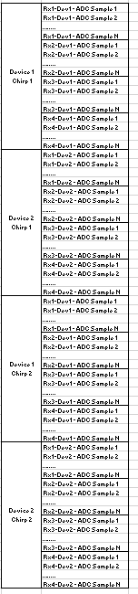

### Antenna Design

The AWR2243-CAS-2X-EVM uses the antenna pattern shown below, with most of the virtual antennas arranged into one row. This allows for finer azimuth resolution, at the cost of elevation resolution.

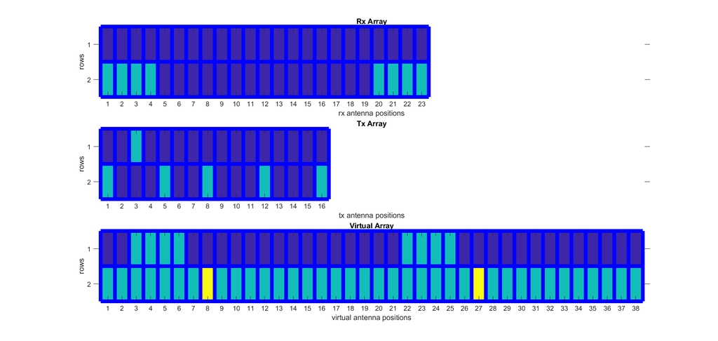

Note that 2 of these virtual antennas overlap with 2 other virtual antennas, making the total of 46 independent channels. The virtual channels are arranged in two rows. The bottom row consists of 40 virtual channels (38 independent virtual channels) that are referred to as ‘Azimuth’ channels. The top row consists of 8 virtual channels that referred to as the ‘Elevation’ channels as they are processed to measure elevation.

Antenna spacing is 0.5 λ in the Azimuth and 0.8 λ in elevation, providing 3° of Azimuth angular resolution.

### Signal Chain

The cascade signal chain is derived from the existing AWR2944/AM273x signal chain (also referred to as data path chain or DPC) from SDK 4.4+. It utilizes DDMA to allow all transmitters to simultaneously transmit, while enabling separation of signals from individual transmitters at each receiver. In DDMA, each transmitter is configured with a ‘frequency’ in slow time (i.e. a particular phase shift per chirp), which imparts a unique offset to the velocity measured from each received target for each transmitter. ADC data is processed by successive fast Fourier transforms (FFTs) in the Range, Doppler, Azimuth dimensions respectively. Between the Doppler and Azimuth FFTs, a demodulation algorithm is used to assign antenna samples to transmitters. Detection algorithms extract notable points, and a tracking algorithm is used to track recurring moving objects.

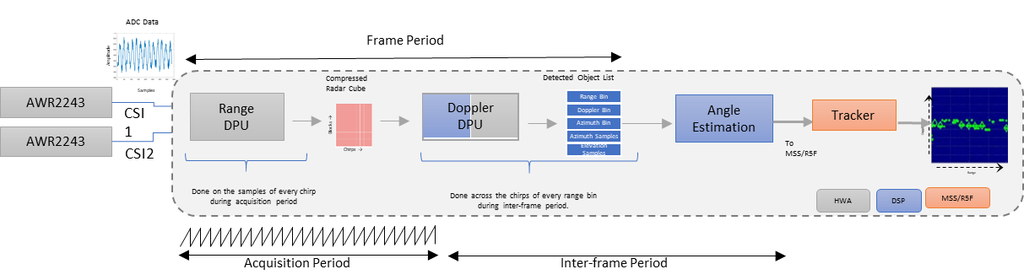

A simplified diagram of the DPC is shown above. The DPC source code is available at `{LAB_DIR}/src/awr2243ti/datapath\\/dpc/objectdetection/objdethwaDDMA/src/objectdetection.c`.

### Datapath Details

A DPC consists of a sequence of DPUs (data path units). Each DPU takes inputs (either ADC data, or range FFT outputs) and sends outputs (either range FFT, or detected objects). It is expected to take care of initialization, resource allocations, processing, and clean up. Three DPUs that are used in this design:

- RangeProcDDMA performs DC subtraction, interference mitigation, windowed range FFT, and compression in sequence on each of the chirps. See `{LAB_DIR}/src/awr2243/ti/datapath/dpu/rangeprocDDMA/src/rangeprochwaDDMA.c`)
- DopplerProcDDMA performs decompression, Doppler FFT,DDMA demodulation, azimuth FFT, 2D local maxima detection (across the azimuth Doppler plane) and CFAR (in the doppler dimension) and create a list of detected objects (per range-gate). After dopplerProcDDMA, a list of detected objects with their range, doppler, and azimuth phase is stored in memory. (see ti\datapath\dpu\dopplerprocDDMA\src\dopplerprochwaDDMA.c)
- RangeCfarProcDDMA Performs CFAR in range dimension using the HWA. (See `{LAB_DIR}/src/awr2243/ti/datapath/dopplerprocDDMA/src/dopplerprochwaDDMA.c`)

### Testing Results

The board has been tested in different contexts for both long range and short range configurations. The beloew figure, shows the detection of a car at 250 meters.

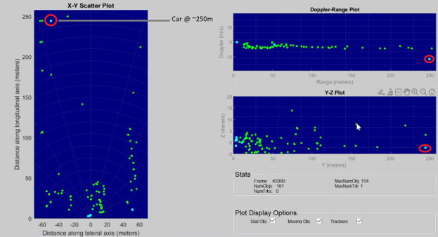

## Notes

### Chirp Design Parameters

- In the profile configuration, the High pass filters’ corner frequencies are configured to 350 kHz (HPF1) and 1.4MHz (HPF2). This is because, we’ve seen instances clipping in the FFT/Front end with lower corner frequencies when there are strong targets (like a building or a car) close to the radar.
- The RxGain parameter is also set to lower values to prevent clipping.

### Known Issues

- The compression algorithm BFP is not supported in this demo.
- Reconfiguration of the chirp design by stopping transmission and then sending another configuration is not supported. To change configuration, power cycle the board, and then send a new configuration.
- Chirp design is limited to 192 adc samples, 256 chirps, and 8 channels. No other configuration has been tested.
- Tracker doesn’t work well at long ranges as it expects more than a few points in a cluster to assign a track. Tracker is not also tuned for close range objects.
- Saturation/P1dB issues may still happen with strong reflectors near the radar.

### Tuning

- More range. One issue we’ve noticed is that when driving the max detection range drops. This is not because of any link budget issue, rather, because the number of detected objects is capped to 800 objects. When in motion, more objects are detected and since the doppler processing module processes range gates in ascending order – closer objects fill up all the available slots. To detect further, there are a few options,
  - Increase doppler SNR in the CFAR command. This can be done by increasing the number in bold in the CFar commands in the cfg file. `cfarCfg -1 1 3 16 0 0 1 17.0 1 7 0 1` `cfarCfg -1 0 3 16 0 0 1 10.0 0 7 0 1`
  - Reduce the local max thresholds to smaller numbers. `localMaxCfg -1 9 25`
  - Modify the number of detected objects per range-gate. This would require a code modification in dopplerproc

### Possible Flashing Issues for New Flash Memory

- If flashing does not work properly on board it is likely that the manufacturer has not set the Quad Enable bit.
- To fix this one must change the Quad Enable Type from 1 to 6. To do this one will have to build their own sbl_uart_uniflash.release.tiimage. Observe the following steps
  - Import the projectspec file from the following directory in the installed SDK `{SDK_DIR}\mcu_plus_sdk_am273x_08_05_00_24\examples\drivers\boot\sbl_uart_uniflash\am273x-evm\r5fss0-0_nortos\ti-arm-clang\example.projectspec` to CCS
  - In this project access the example.syscfg file and go to the FLASH page. From there change “Quad Enable Type” parameter to 6. Rebuild the CCS project, take the .tiiimage created and place it in `{LAB_DIR}\prebuilt_binaries`. From there edit the demo.cfg file to ensure one is using the intended sbl_uart_uniflash.tiimage. Flash as in instructed in the Flash Lab Binaries section.

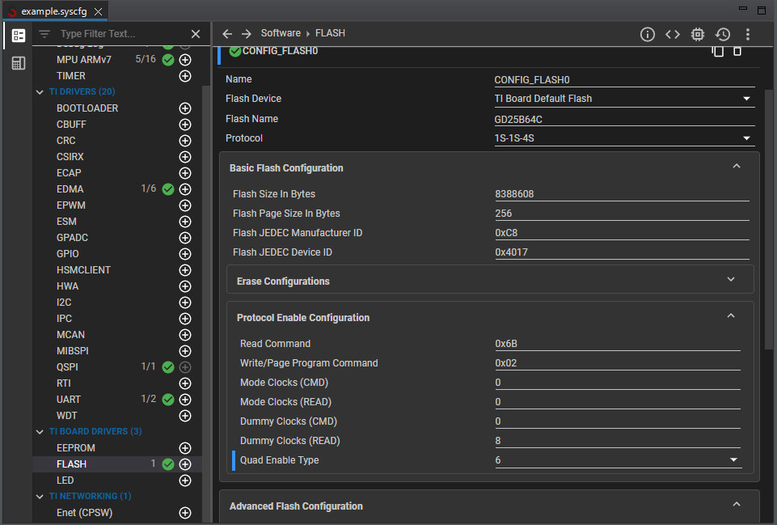

- This ensures that the QE bit is written and flashing should work properly.
- Once this is completed one can edit the demo.cfg file to use the original sbl_uart_uniflash.tiimage again.